# Gamma Clustering and Pathway Analysis

Anooj Arkatkar, Abigail Schuch

# Introduction

With the recent explosion in large-scale biological datasets, there is a need for robust models capable of intuitively analyzing them. `gClustPath` , or *Gamma Clustering and Pathway Analysis,* presents two models that prioritize ease of interpretation.

- Gamma clustering: Maximize the likelihood of a null model producing all inter-cluster correlations and no intra-cluster correlations.
- Gamma pathway analysis: Minimize the likelihood of a null model producing any linking correlation within a pathway.

# The math.

The namesakes of *Gamma Clustering and Pathway Analysis* are two quantities derived from the p-value of a pairwise correlation.

$$pSig=-log(p)$$

$$pComp=-log(1-p)$$

The sum of *pSig* decreases with the probability of observing all correlations under a null model. The sum of *pComp* increases with the probability of observing at least one correlation under a null model. *pSig* and *pComp* are exponentially distributed variables, and the sum of i.i.d. exponential variables follows a **gamma distribution.**

## Gamma clustering

For each gene $i$ and cluster $j$ , gamma-test the *pSig* and *pComp* sum to all genes in the cluster.

$$C_{i,j}=P(s>\Sigma (pComp)_{i,j})$$

$$S_{i,j}=P(s>\Sigma (pSig)_{i,j})$$

In each iteration, the membership probability $m$ for a gene $i$ in cluster $j$ is defined.

$$m_{i,j}=C_{i,j}*\prod_{k \neq j}{S_{i,k}}$$

Additionally, a void cluster is introduced corresponding to all correlations being null.

$$m_{i,void}=\prod_{k=1}^{n}{S_{i,k}}$$

The algorithm begins with all genes assigned to a single cluster. The divisive phase ends when the void cluster no longer decreases in size. At this point, the optimization phase begins, where clusters are maximally separated by non-correlation.

$$m_{i,j}=\prod_{k \neq j}{S_{i,k}}$$

The optimization phase ends when no genes have assigned to a new cluster.

## Gamma pathway analysis

*pComp* can used as a meaningful dissimilarity measure for a relevant graph algorithm. For pathway analysis, this would be a shortest path algorithm, which finds a pathway connecting two points to minimize the total *pComp* across all connections:

$$minPath = argmin_{pathways}({\Sigma( pComp}))$$
This finds the series of correlations such that a null model would have the smallest likelihood of observing any linking correlation.

# Initializing a workflow

The first step in gamma clustering is loading the `gClustPath` library and the relevant data. Data should be stored in a matrix with rows corresponding to features (i.e., genes) and columns corresponding to samples.

```r
library(gClustPath)
data("foldChange")
dim(foldChange)
```

```
#> [1] 932  14
```

## pMatrix

All gamma clustering methods operate on a matrix of p-values. This can be obtained using the `pMatrix` function. By default, a ranking function is used to force this matrix to follow an exact uniform distribution. This is necessary for gamma clustering, but not gamma pathway analysis. The `output` argument should be used to switch between uniform (“unif”) and original (“orig”) p-values.

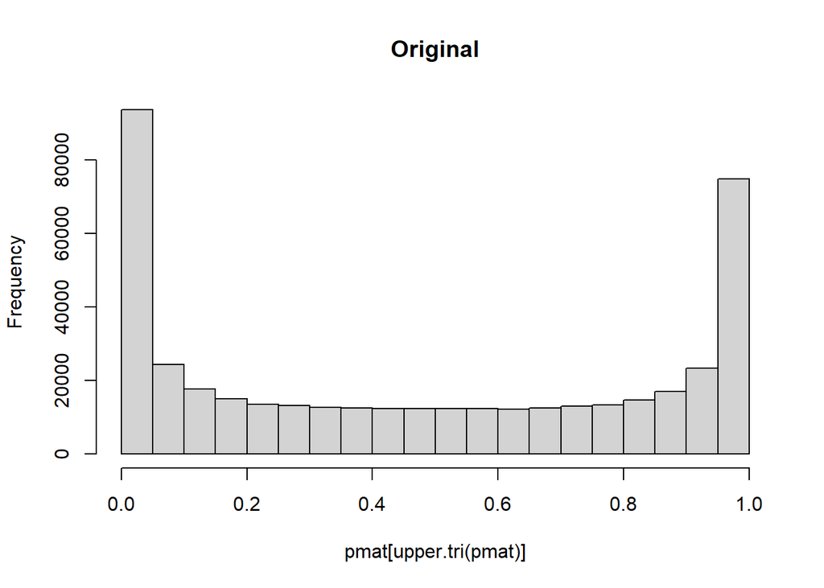

```r
pmat <- pMatrix(foldChange, output="orig")
hist(pmat[upper.tri(pmat)], main="Original")
```

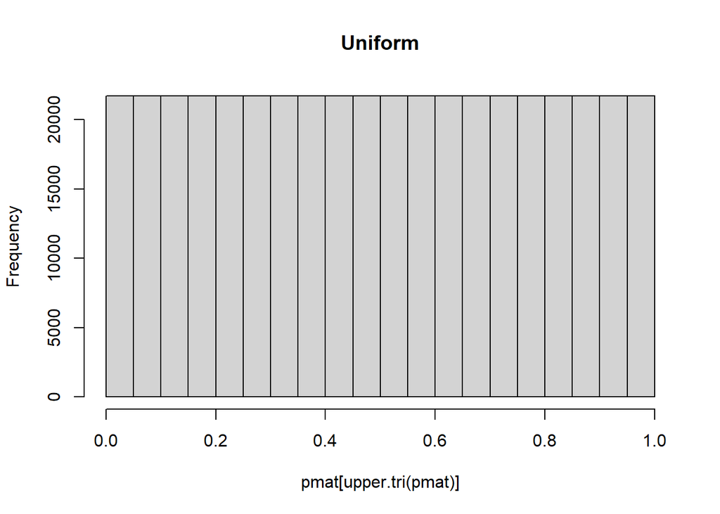

```r
pmat <- pMatrix(foldChange, output="unif")
hist(pmat[upper.tri(pmat)], main="Uniform")
```

## Simple clustering

For simple clustering, use the `gammaCluster` function. For visualizing these clusters, use `gammaPlot`

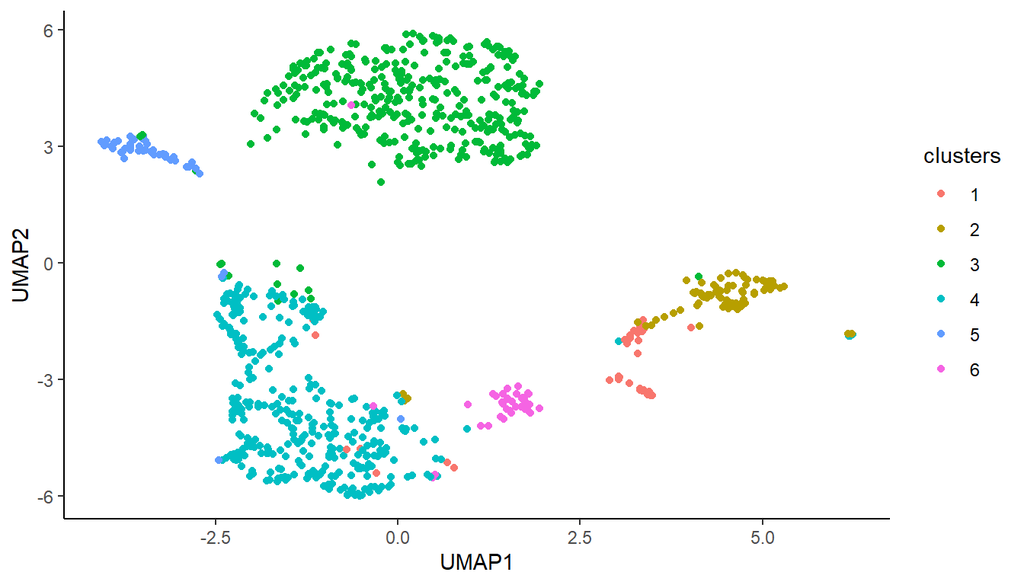

```r
clst <- gammaCluster(pmat)
gammaPlot(pmat, clst$labels)
```

## Recursive clustering

Subsequently, gamma clustering can operate on each individual cluster, producing sub-clusters, before a final optimization step combines correlated clusters. This process can be repeated until clustering converges, or the necessary amount of precision is reached.

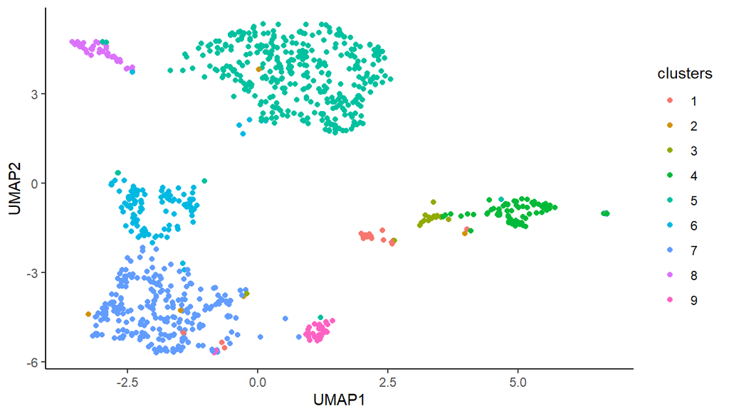

```r
rclst <- recGamma(pmat, clst$labels)
rclst2 <- recGamma(pmat, rclst$labels)
gammaPlot(pmat, rclst2$labels)
```